# Part II - FordGoBike Trips... Who shares their trip?

## by Aishat Adeyemo

## Investigation Overview

In this exploratory analysis, I want to look at the attributes of users/trips that could be used to predict whether a trip would be shared or not. The focus of interests are user type, gender, age, and period of trip.

## Dataset Overview

This data set includes information about individual rides made in a bike-sharing system covering the greater San Francisco Bay area. It contains trips and attributes for approximately 183,500 trips taken in the month of February, year 2019. The attributes include user's biodata, user type (subscriber/non-subscriber), trip duration, trip start and end time, and start/end locations.

## Percentage of Shared Trips and Unshared Trips

Only 9% of the trips taken in the month February were shared. i.e, 1 out of 11 trips were shared.

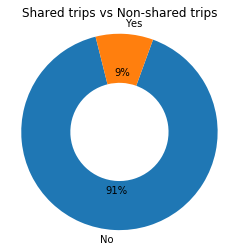

## Distribution of Users' Ages

Users of the bike hailing services are as young as 21 years and as old as 144 years. The highest users are about 36 years old.

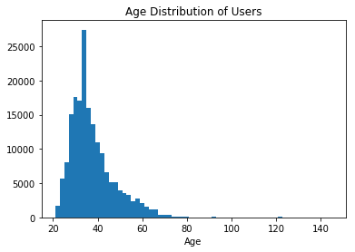

## Distribution of Trip Duration in minutes

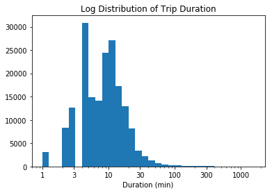

## When are the peak periods?

The peak periods are Morning and Evening. This periods corresponds with when most people leave thier homes for the day's business and when they return to their homes at the close of the day respectively.

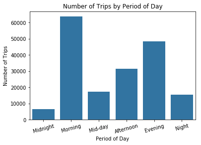

## Which Gender took the most trips?

The Male gender took the most trips in the month of February, followed by the Female gender. The Other gender were the least users of the bike share service.

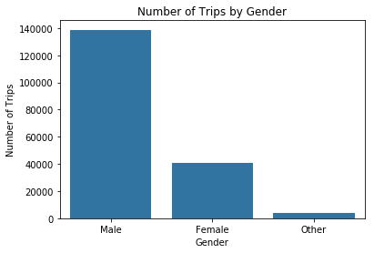

## What category of users shared their trips?

Only subscribers of the bike services shared their trips. From the gender point of view, the male gender shared their trips more than the female and the other gender. The order of shared trips by user category is as follows;

> Male subscriber > Female subscriber > Other subscriber

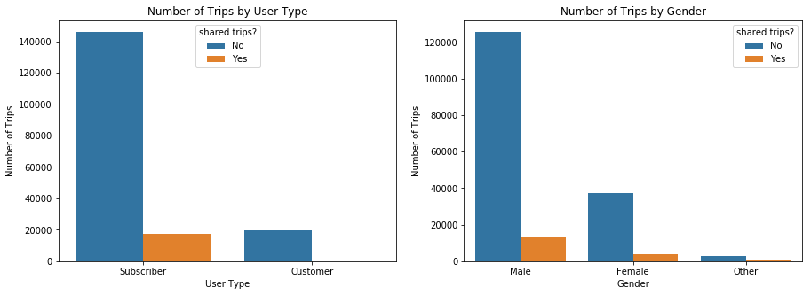

## What age group do the people who share their trips belong and what's the duration of their trips?

The users who shared their trips have an average age that ranges from 35-40. They were most males that were less than 36 years old. Their trips lasted for an average of 10-15 minutes and they were mostly under 11 minutes also taken by the Male gender.

```
Text(0.5,1,'Avg Age of User by Gender')
```

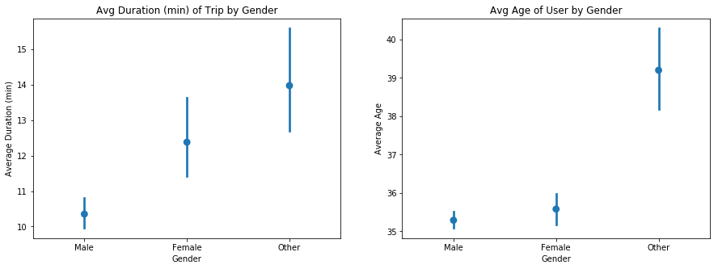